# 36-315 Homework 08, Spring 2017

## c.

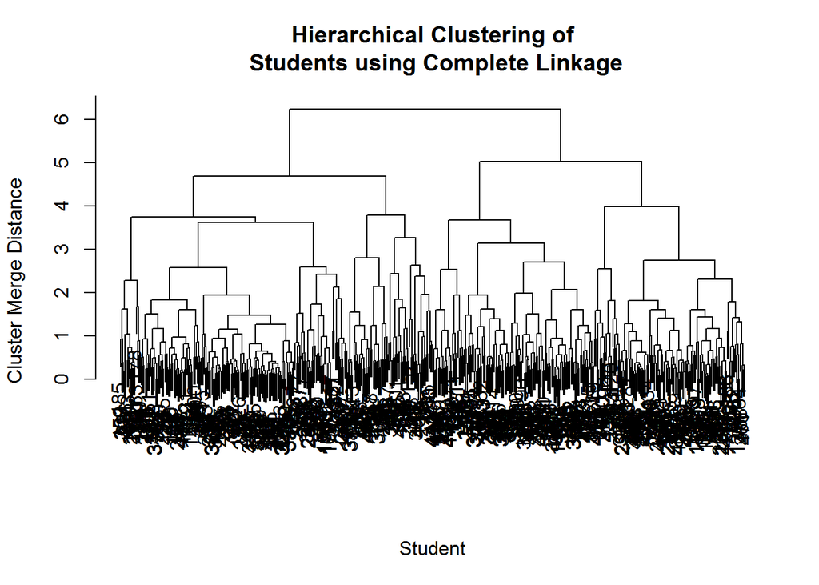

```r
plot(hc_student_complete, xlab = "Student",
     ylab = "Cluster Merge Distance",
     sub = "",
     main = "Hierarchical Clustering of\n Students using Complete Linkage")
```

`plot()` uses a dendrogram to visualize the hierarchical clustering results.

## d.

The maximum distance at which two observations are linked can be see in the dendrogram by the highest horizontal bar. This occurs at a height of roughly 6.

## e.

Of the two groups linked in the final iterations of hierarchical clustering, both clusters seem to have about 50% of the observations.

## f.

```r
labels_complete_2 <- cutree(hc_student_complete, k = 2)
```

`labels_complete_2` is a vector of integers containing 480 elements. Note that this is the same as the number of students in the data set.

## g.

```r
table(labels_complete_2) / nrow(student)
```

```
## labels_complete_2
##   1   2
## 0.5 0.5
```

Exactly 50% of the observations are in each of the clusters at the highest split.

## h.

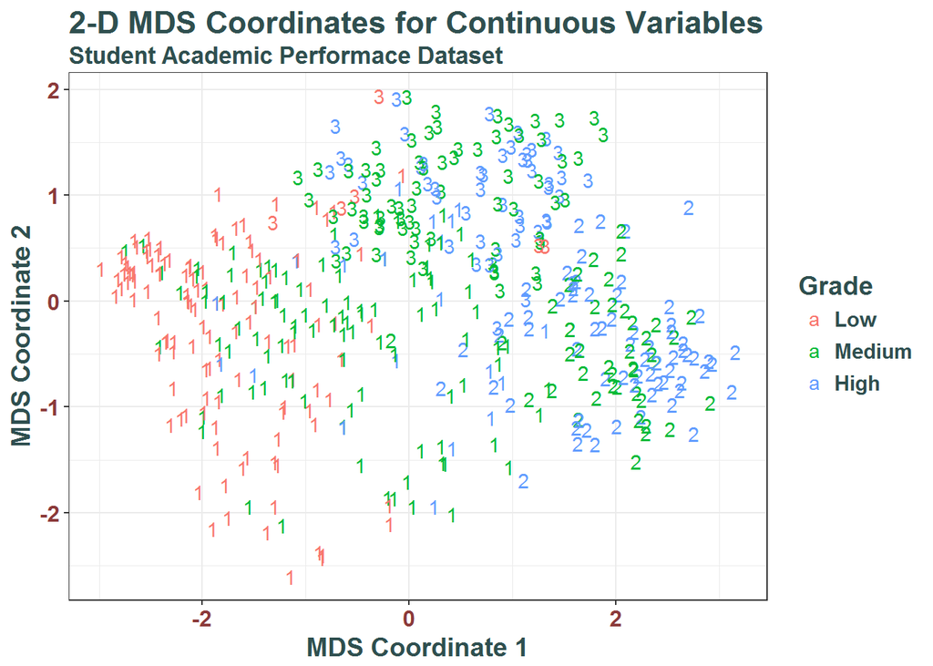

```r
library(forcats)
labels_complete_3 <- cutree(hc_student_complete, k = 3)

student_mds <- dist_student %>%
  cmdscale(k = 2) %>%
  as.data.frame() %>%
  mutate(Grade = student$Grade,
         AbsentDays = student$AbsentDays,
         Labels = labels_complete_3)

colnames(student_mds)[1:2] <- c("mds_coordinate_1", "mds_coordinate_2")
student_mds$Grade <- student_mds$Grade %>%
  fct_recode(Low = "L",
             Medium = "M",
             High = "H") %>%
  fct_relevel("Low", "Medium", "High")

ggplot(data = student_mds,
       aes(x = mds_coordinate_1, y = mds_coordinate_2,
           color = Grade, label = Labels)) +
  geom_text() +
  labs(title = "2-D MDS Coordinates for Continuous Variables",
       subtitle = "Student Academic Performace Dataset",
       x = "MDS Coordinate 1",
       y = "MDS Coordinate 2") +
  my_theme
```

Most of the low grade students are in cluster 1, although the reverse is not true. The medium grade students seem to be split relatively evenly amongst all the clusters, while most of the high grade students are in clusters 2 and 3.

## i.

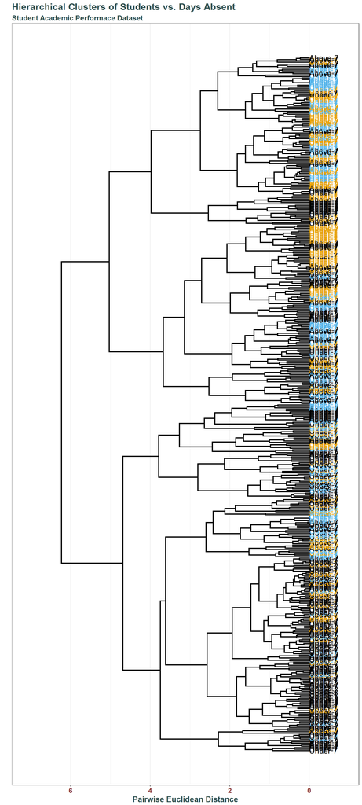

```r
library(dendextend)

get_colors <- function(x, palette = my_colors) palette[match(x, unique(x))]

student %>%
  dplyr::select(RaisedHands, VisitedResources,
                AnnouncementsView, Discussion) %>%
  scale() %>%
  dist() %>%
  hclust(method = "complete") %>%
  as.dendrogram %>%
  set("labels", student_mds$AbsentDays,
      order_value = TRUE) %>%
  set("labels_col", get_colors(student_mds$Labels),
      order_value = TRUE) %>%
  ggplot(horiz = T) +
  my_theme +
  labs(title = "Hierarchical Clusters of Students vs. Days Absent",
       subtitle = "Student Academic Performace Dataset",
       y = "Pairwise Euclidean Distance",
       x = "") +
  scale_x_continuous(breaks = NULL)
```

## j.

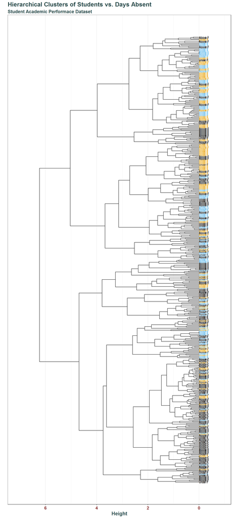

```r
library(dendextend)

get_colors <- function(x, palette = my_colors) palette[match(x, unique(x))]

student %>%
  dplyr::select(RaisedHands, VisitedResources,
                AnnouncementsView, Discussion) %>%
  scale() %>%
  dist() %>%
  hclust(method = "complete") %>%
  as.dendrogram %>%
  set("labels", student_mds$AbsentDays,
      order_value = TRUE) %>%
  set("labels_col", get_colors(student_mds$Labels),
      order_value = TRUE) %>%
  set("labels_cex", 0.5) %>%
  set("branches_lwd", 0.5) %>%
  ggplot(horiz = T) +
  my_theme +
  labs(title = "Hierarchical Clusters of Students vs. Days Absent",
       subtitle = "Student Academic Performace Dataset",
       y = "Height",
       x = "") +
  scale_x_continuous(breaks = NULL)
```

# Problem 6

**Hexagonal Bin Plots**

(1 point each)

Look up at the [documentation on hexagonal bin plots](http://docs.ggplot2.org/current/geom_hex.html).

1. (1 point) What kind of plot is a hex-bin plot very similar to?
2. Create a hex-bin plot with the student performance data, with `RaisedHands` on the x-axis and `AnnouncementsView` on the y-axis. Use a non-default color scheme. Try at 2-3 different values of the `bins` parameter (e.g. 8, 12, 20). What does this specify? What happens when you increase or decrease the `bins` parameter?
3. Where are the highest-density areas of the joint distribution of `RaisedHands` and `AnnouncementsView`?
4. Find one example of the use of hexagonal bin plots online. (Hint: Search “hex bin plots basketball” or “hex bin plots hockey”, or “hex bin plots baseball”.) Describe the example you found and provide a link.

### Sam Says

- Hex-bin plots can be extended so that you can specify both the size of the hexagons (proportional to the frequency of observations in that area) and the color of hexagons (proportional to some other continuous variable for observations in that area). This idea was championed by Kirk Goldsberry, a cartographer who now works applies statistical analysis and data visualization to basketball. These are awesome plots.
- Unfortunately, there is no `ggplot()` implementation for this already. If anyone wants to design one for course credit or academic credit, please contact Sam! (Note: This will not be easy.)
- Hex-bin plots are nice when you have a very large number of observations. For smaller datasets like the `student` dataset, they are typically not as useful as contour plots and heat maps, since they require a small number of large bins to get a good picture of the density of observations.

# Problem 7

(2 points each)

**Criticize the Lab 08 Oral Evaluation Graphic**

On Lab 08, the Oral Evaluation Graphic was something called a “Spider Chart” or “Radar Chart” or “Star Plot”. You can read more about this type of chart [here](http://www.datavizcatalogue.com/methods/radar_chart.html).

Critique the chart from the Lab 08 Oral Evaluation:

1. Describe at least two good qualities of the chart.
2. Describe at least two bad qualities of the chart.
3. Is there any distortion in radar charts? If so, explain how.

# BONUS

(BONUS: 10 points)

**Beyond Default Pairs Plots**

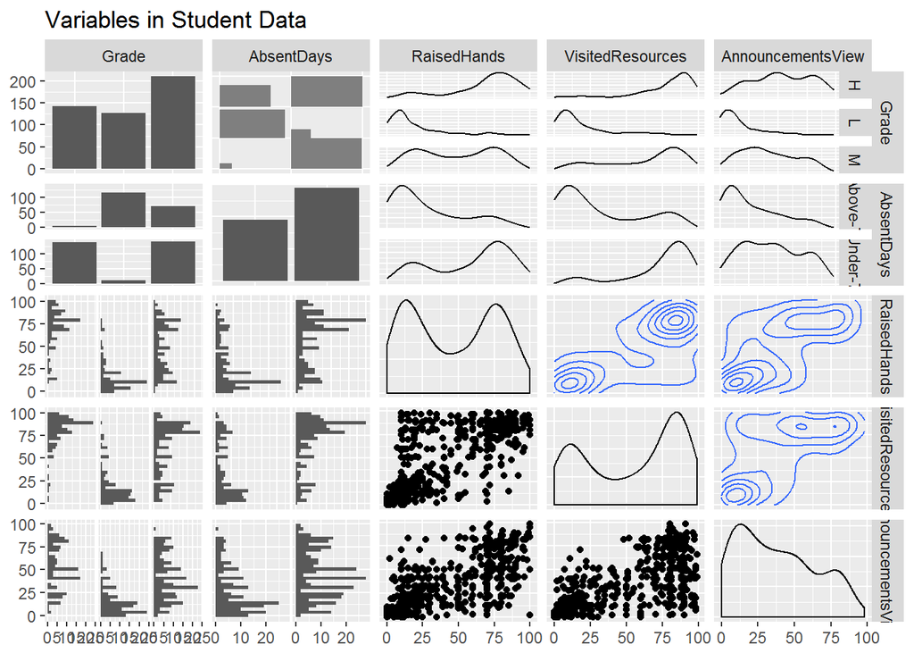

```r
library(GGally)

student_sub <- student %>%
  dplyr::select(Grade, AbsentDays, RaisedHands,
                VisitedResources, AnnouncementsView) %>%
  mutate(Grade = factor(Grade), AbsentDays = factor(AbsentDays))

student_sub %>%
  ggpairs(upper = list(continuous = "density",
                               discrete = "ratio",
                               combo = "facetdensity"),
                  title = "Variables in Student Data")
```